# MAPS Majors Historical Data

Jason Preszler

September 16, 2018

The following table gives the major codes (used by the registrar and institutional research) an names for each major. Throughout this document we will primarily use the codes to refer to each major.

| code | name |
| --- | --- |
| MAPHD | Math-Physics ??? |
| MAT | Mathematics |
| MATCS | Math-CS |
| MATPH | Math-Physics |

The current catalog (2018-2019) lists 10 NSM majors. Other peaks have similar numbers of majors - 12 in HFA, 7 in SSH, and 6 in PSE.

## Data Acquisition and Preparation

The data was provided by the Registrar and Director of Institutional Research. It includes all students with graduation year 2013 or later. The original dataset included some students from earlier, pre-PEAK, years who have been removed. Identifying information including name and ID number have been removed, as have additional variables of graduation date, graduation term, degree (BA or BS), and “Concentration”. A generic ID was added to to connect the multiple minors and majors together (as a single student) when reshaping data but this has no connection to the student ID. Leading and trailing white-space from all non-numeric variables was also removed which was necessary since some minor codes has leading spaces during earlier years.

## Overview of Data

The data shows that the 1182 students received 78 different minors and 36 different majors.

## Major Counts over Time

First we look at the overall count of students received any MAPS major, then we see how those counts are spread over time.

| major | count |
| --- | --- |
| MAPHD | 11 |
| MAT | 50 |
| MATCS | 33 |
| MATPH | 143 |

|  | 2013 | 2014 | 2015 | 2016 | 2017 | 2018 |
| --- | --- | --- | --- | --- | --- | --- |
| MAPHD | 4 | 5 | 1 | 1 | 0 | 0 |
| MAT | 9 | 9 | 24 | 2 | 3 | 3 |
| MATCS | 4 | 2 | 3 | 9 | 15 | 0 |
| MATPH | 16 | 39 | 25 | 29 | 34 | 0 |

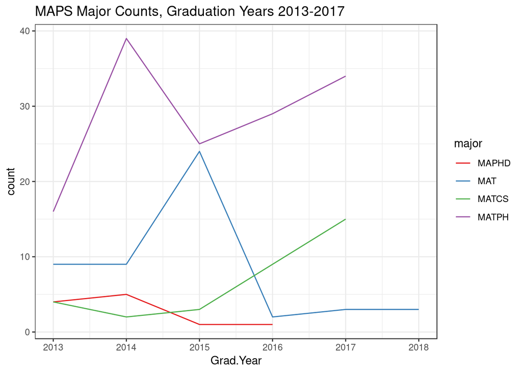

## Major-Minor Associations

Below we have a table of the majors in MAPS and minors with more than 4 students earning that major/minor combination.

| major | minor | count |
| --- | --- | --- |
| MATPH | PSY | 18 |
| MATPH | CSC | 13 |
| MATCS | PSY | 11 |
| MATPH | HIS | 11 |
| MAT | PSY | 9 |
| MATPH | ARTDE | 9 |
| MATPH | DUENG | 7 |
| MAPHD |  | 6 |
| MAT | BUS | 6 |
| MATPH | PHI | 6 |
| MATPH | BUS | 5 |
| MATPH | REL | 5 |

## Chord Diagram of MAPS Majors

[interactive chart not shown]